# Associations

Maggy Critchlow

11/4/2020

## Data and Required Packages

```r
library(tidyverse)
library(dslabs)
library(ggrepel)
library(ggsci)
library(gridExtra)
data(gapminder)
head(gapminder)
```

```
##               country year infant_mortality life_expectancy fertility
## 1             Albania 1960           115.40           62.87      6.19
## 2             Algeria 1960           148.20           47.50      7.65
## 3              Angola 1960           208.00           35.98      7.32
## 4 Antigua and Barbuda 1960               NA           62.97      4.43
## 5           Argentina 1960            59.87           65.39      3.11
## 6             Armenia 1960               NA           66.86      4.55
##   population          gdp continent          region
## 1    1636054           NA    Europe Southern Europe
## 2   11124892  13828152297    Africa Northern Africa
## 3    5270844           NA    Africa   Middle Africa
## 4      54681           NA  Americas       Caribbean
## 5   20619075 108322326649  Americas   South America
## 6    1867396           NA      Asia    Western Asia
```

This data set encompasses several variables measuring human wellbeing, such as infant mortality, life expectancy, and GDP. We will be seeing how two variables, Dollars per Day and Infant Survival Rate, have changed globally through the years. These are not existing variables in the table, but are calculated as following:

```r
gap2010 <- gapminder %>%
  filter(year == 2010 & !is.na(gdp) & !is.na(infant_mortality)) %>%
  mutate(dollars_per_day = gdp/population/365) %>%
  mutate(infant_survival_rate = 1 - infant_mortality/1000)
head(gap2010)
```

```
##               country year infant_mortality life_expectancy fertility
## 1             Albania 2010             14.8            77.2      1.74
## 2             Algeria 2010             23.5            76.0      2.82
## 3              Angola 2010            109.6            57.6      6.22
## 4 Antigua and Barbuda 2010              7.7            75.8      2.13
## 5           Argentina 2010             13.0            75.8      2.22
## 6             Armenia 2010             16.1            73.0      1.55
##   population          gdp continent          region dollars_per_day
## 1    2901883   6137563946    Europe Southern Europe        5.794597
## 2   36036159  79164339611    Africa Northern Africa        6.018638
## 3   21219954  26125663270    Africa   Middle Africa        3.373106
## 4      87233    836686777  Americas       Caribbean       26.277814
## 5   41222875 434405530244  Americas   South America       28.871158
## 6    2963496   4102285513      Asia    Western Asia        3.792527
##   infant_survival_rate
## 1               0.9852
## 2               0.9765
## 3               0.8904
## 4               0.9923
## 5               0.9870
## 6               0.9839
```

## Earnings and Infant Mortality in 2010

Before I make this plot, I’m going to set up a custom color palette to ensure uniformity between my 1960 and 2010 graphs. I’m going to use the Futurama color palette from the excellent `ggsci` package.

```r
col.pal <- pal_futurama(palette = "planetexpress")(5)
```

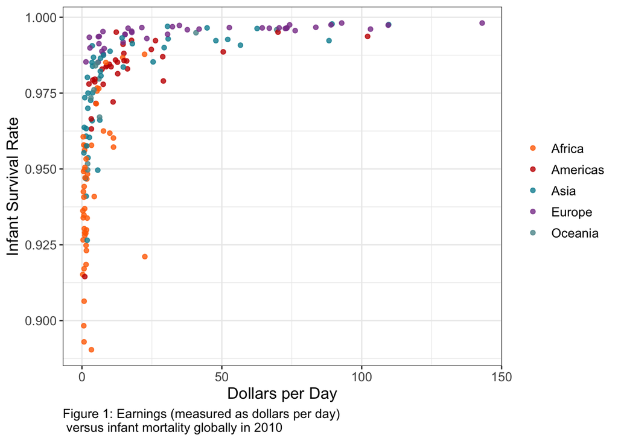

```r
plot1 <- ggplot() + geom_point(data = gap2010, aes(x = dollars_per_day, y = infant_survival_rate, color = continent), alpha = 0.8) + theme_bw() + labs(x = "Dollars per Day", y = "Infant Survival Rate", caption = "Figure 1: Earnings (measured as dollars per day) \n versus infant mortality globally in 2010") + theme(text = element_text(size=13), plot.caption = element_text(hjust = 0), legend.title = element_blank()) + scale_color_futurama()
plot1
```

Hmm. This graph does seem to show a positive relationship between earnings (expressed as dollars per day), and infant survival, but many countries clustered around the lower earnings have a wide range of infant survival outcomes. Differences in continents can be broadly observed, with Europe having a much wider range of earnings than Africa. However, this plot is not as helpful as it could be. It has many overlappoing points, and there is almost as much variation within continents as there is between them. Let’s try graphing each of the continents separately.

### Earnings and Infant Mortality in 2010 by Country

```r
gap2010afr <- gap2010 %>% filter(continent == "Africa")
gap2010am <- gap2010 %>% filter(continent == "Americas")
gap2010oc <- gap2010 %>% filter(continent == "Oceania")
gap2010eu <- gap2010 %>% filter(continent == "Europe")
gap2010asia <- gap2010 %>% filter(continent == "Asia")
```

After filtering the data, as shown above, it’s simple to construct a graph showing dollars per day vs infant survival for each continent. This makes it a little easier to see where differences might lie, although it does make it a little harder to compare the continents directly. I waffled so much on whether to make these plots tabbed or in a grid that I’m now considered a Kellogg’s factory. One of the biggest things was matching the axes. In order to put the plots in a grid, the axes should be the same (not doing so would be bad, as the grid would invite the reader to compare each plot directly, despite the scales being different), but making the axes equal caused the same problem seen in the overall graph above, where pretty much all of the countries in Africa and half of Asia were smushed against the y-axis. The current set up with varied axis lengths makes it harder to compare the continents, but some interesting patterns emerge by region within the continents.

#### Africa

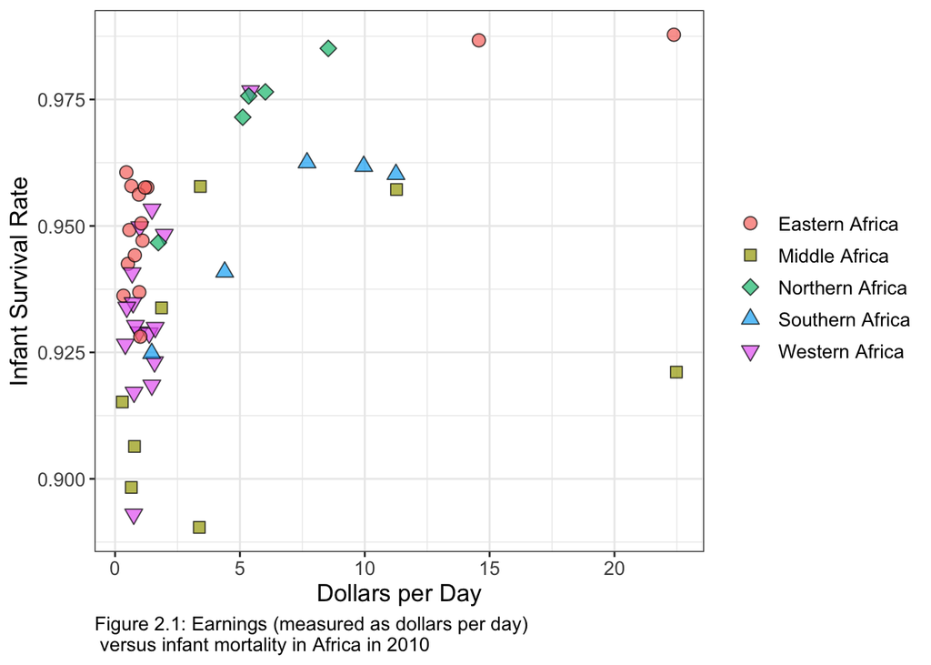

```r
plot.afr <- ggplot() + geom_point(data = gap2010afr, aes(x = dollars_per_day, y = infant_survival_rate, fill = region, shape = region), size = 3, alpha = 0.7) + theme_bw() + labs(x = "Dollars per Day", y = "Infant Survival Rate", caption = "Figure 2.1: Earnings (measured as dollars per day) \n versus infant mortality in Africa in 2010") + theme(text = element_text(size=13), plot.caption = element_text(hjust = 0), legend.title = element_blank()) + scale_shape_manual(values = c(21:25)) + scale_color_locuszoom()
plot.afr
```

#### Americas

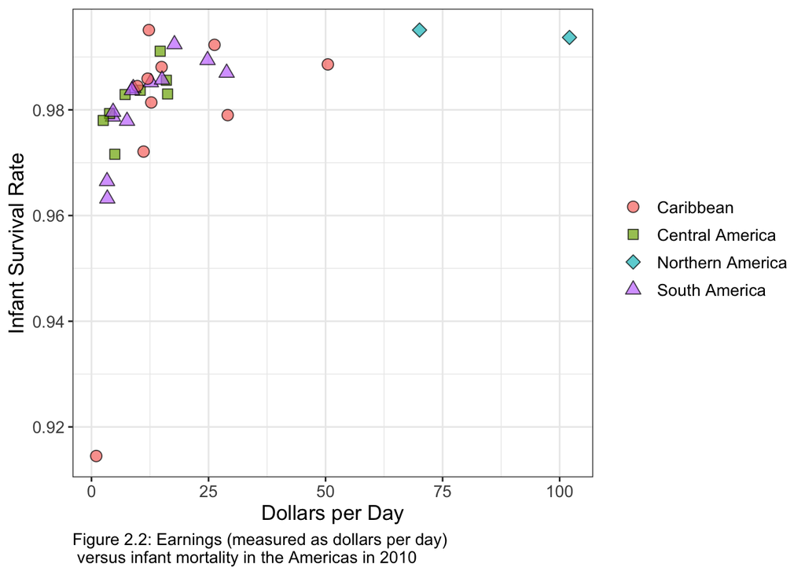

```r
plot.am <- ggplot() + geom_point(data = gap2010am, aes(x = dollars_per_day, y = infant_survival_rate, fill = region, shape = region), size = 3, alpha = 0.7) + theme_bw() + labs(x = "Dollars per Day", y = "Infant Survival Rate", caption = "Figure 2.2: Earnings (measured as dollars per day) \n versus infant mortality in the Americas in 2010") + theme(text = element_text(size=13), plot.caption = element_text(hjust = 0), legend.title = element_blank()) + scale_shape_manual(values = c(21:25)) + scale_color_locuszoom()
plot.am
```

#### Asia

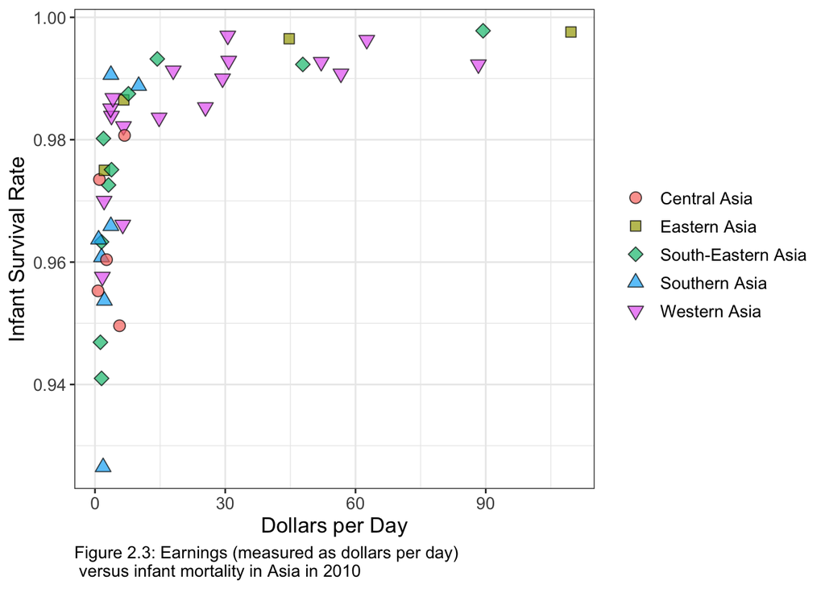

```r
plot.asia <- ggplot() + geom_point(data = gap2010asia, aes(x = dollars_per_day, y = infant_survival_rate, fill = region, shape = region), size = 3, alpha = 0.7) + theme_bw() + labs(x = "Dollars per Day", y = "Infant Survival Rate", caption = "Figure 2.3: Earnings (measured as dollars per day) \n versus infant mortality in Asia in 2010") + theme(text = element_text(size=13), plot.caption = element_text(hjust = 0), legend.title = element_blank()) + scale_shape_manual(values = c(21:25)) + scale_color_locuszoom()
plot.asia
```